# 单变量绘图选择

其实拖欠天数是对耗损影响有最大影响的，同时评级也影响着拖欠天数和初始金额，所以猜测评级和初始金额可能通过和拖欠天数的关系，也影响贷款耗损。

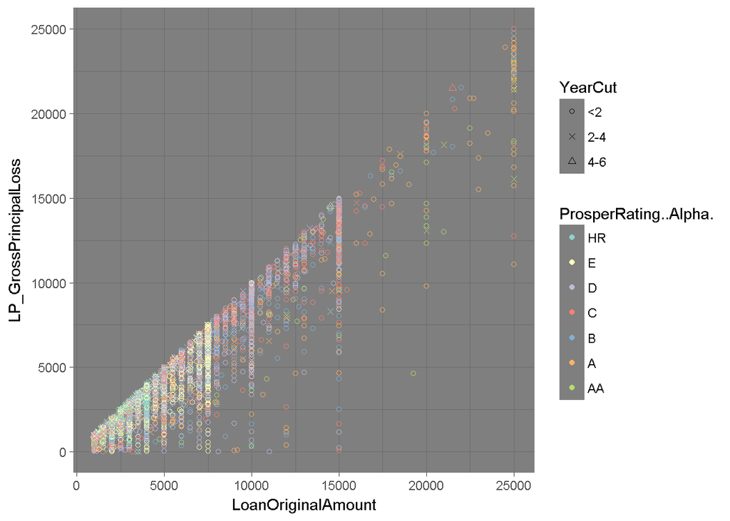

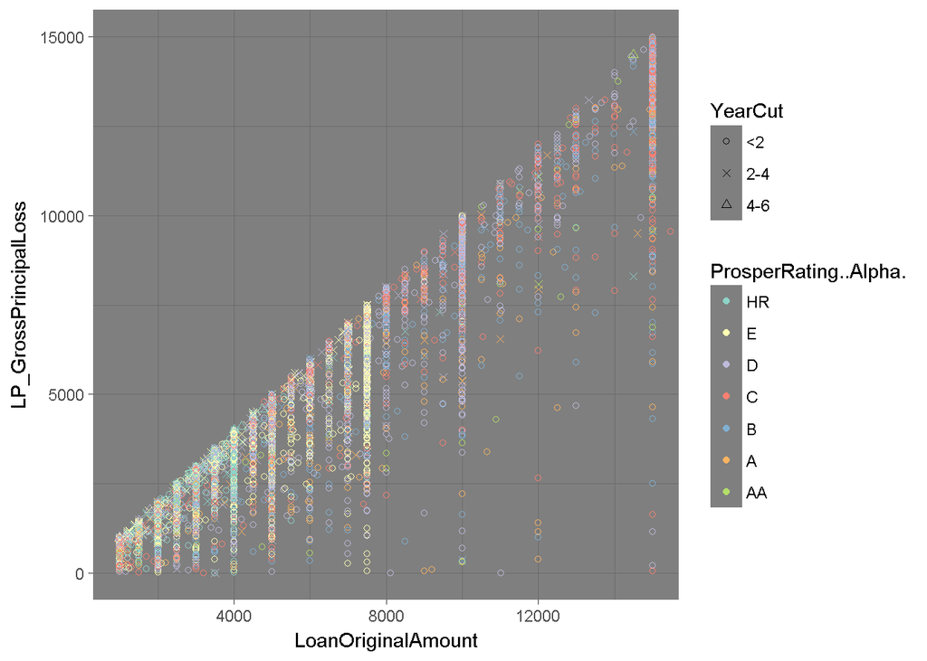

只看有耗损的记录，可以发现确实是贷款初始金额越高，若是发生耗损的话，那么也一定是水涨船高，且高额耗损的信用评级也高，原因可能是低信用评级的借款额度不会很高。但是高额耗损的拖欠天数基本都是2年以内，只看到一个4-6年的点且信用评级是C。其中有趣的一点是，我们并没有看到大于6年的点，猜测原因可能是记录中信用评级未知。放大集中区域，也会发现这些点呈现着信用评级的分层和竖条状分布。而且拖欠年数还是以小于2年居多，无论是耗损高低。2-4年的拖欠也基本集中在低耗损区域。和上面耗损-拖欠时间的分布不同的一点是，图中4-6年拖欠的点数并不多，可能是这些记录的信用评级都未知。

最后，可以将贷款初始金额换成和信用评级有着密切关系的风险系数，来查看评级和风险系数怎样通过拖欠天数影响着耗损。

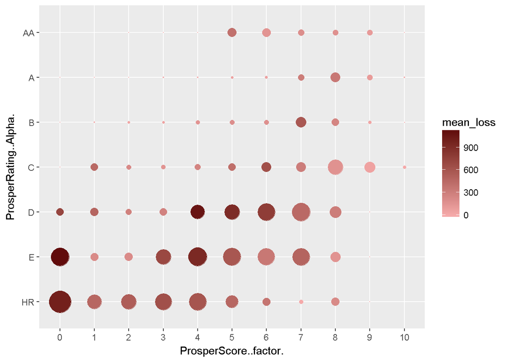

可以直接看到的是，大面积的点基本集中在低评级，HR-0是一个很危险的特征，这个特征往往表示长时间的拖欠、高耗损、低回报，当然贷款初始额也不会很高。4、5、6、7虽然有着高预估回报（上图显示），但也存在拖欠时间和耗损稍大的风险。最安全——低耗损、拖欠短的就是高风险系数（高安全性）且信用评级高，但是正如前一图所示，回报也低。

# 多变量分析

### 探讨你在这部分探究中观察到的一些关系。通过观察感兴趣的特性，是否存在相互促进的特性？

一般来说信用评级和风险系数（安全性）都是双高或者双低的。耗损随着二者的增加而降低，但是预估回报也在降低。高额贷款基本发生在高信用评级上，因此不能单纯说，贷款本金越高预估回报就越高，反而这些高额贷款的回报最后只收敛于0.05-0.1的回报区间内。虽然也有高回报且低耗损，但不排除那些记录属于异常的可能。因此可以总结为越安全，贷款金额越大，但是耗损越小，可同时预估回报也越小；越危险，贷款金额越小，但是损失越大（不会超过本身贷款金额，是同高信用评级和安全性来比较），但是预估回报也越大。

### 这些特性之间是否存在有趣或惊人的联系呢？

贷款初始金额越高，如果发生耗损的话，耗损金额也会水涨船高。正如上面说的，高额贷款基本发生在高信用评级上，因此高信用评级的预估回报也可能是受此影响。

### 选项：你是否创建过数据集的任何模型？讨论你模型的优缺点。

# 定稿图与总结

### 绘图一

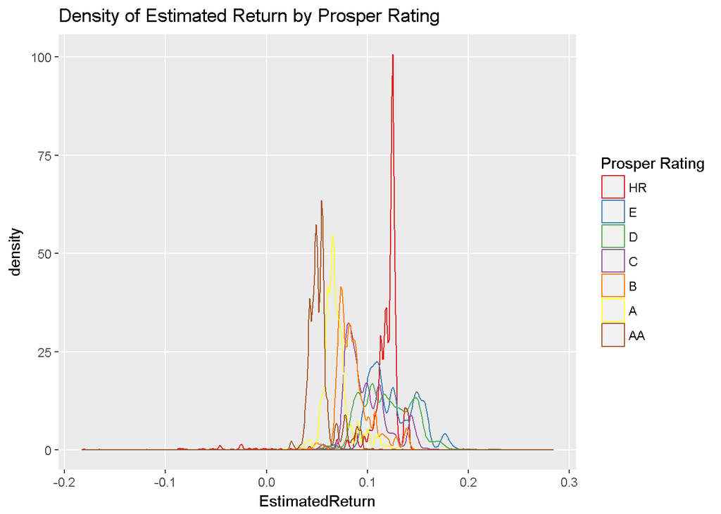

### 描述一

B、A、AA这三个评级的回报分布随着信用评级的升高而往低回报方向平移，且低回报的密度还在升高。D和E在稍高回报的区间分布较广且平缓，HR的高回报区间虽然窄，但是密度分布却有个不小的高峰，但HR也有着低回报甚至是负回报的记录。但总体上可以看出来，预估回报是随着信用评级的升高而降低的。

### 绘图二

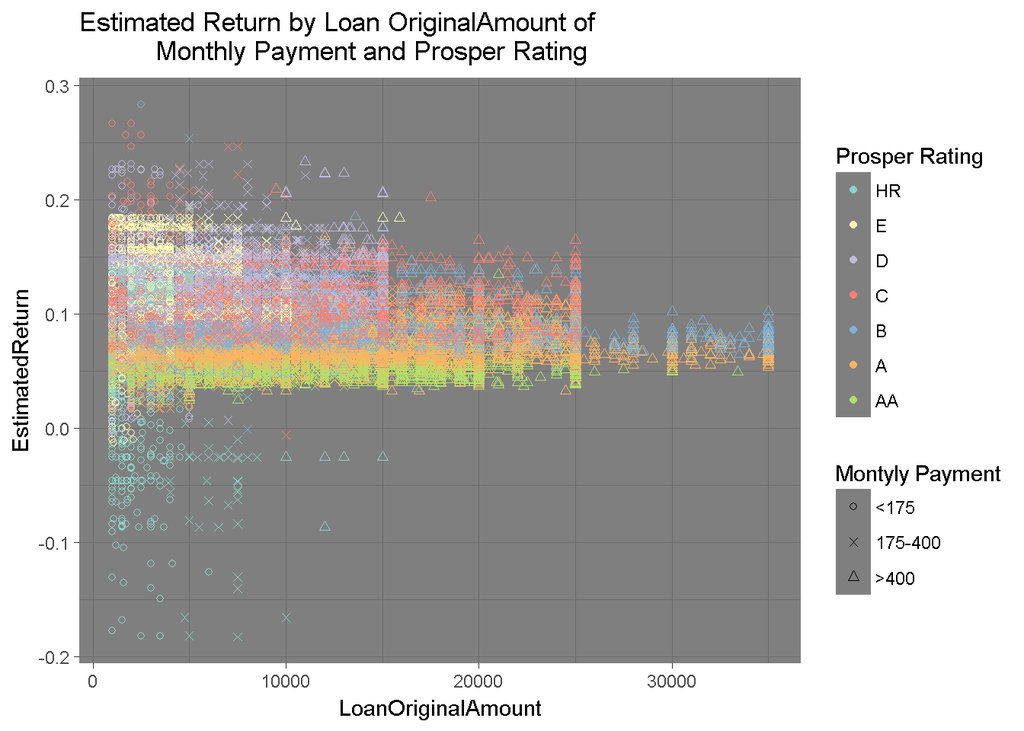

### 描述二

信用评级在预估回报的分布上明显存在着分层，这和上面的不同信用评级下的预估回报分布所显示的结果一样。大于25000的高额贷款的密度很低，在x轴的方向上，似乎存在一个小于10000元贷款和大于10000小于25000的分层。可以发现，高额贷款的预估回报并不高只是最终收敛于0.05-0.1的回报区间内。将图片聚焦到密集范围内，会发现按月还贷额的三个cut正好分别集中在贷款初始额的三个区间内，但并不是完全分割，还是各有掺杂。而且可以看出来图中的点是呈竖条状分布的，因为人们一般很少是有零有整的贷款，一般都是取整。

### 绘图三

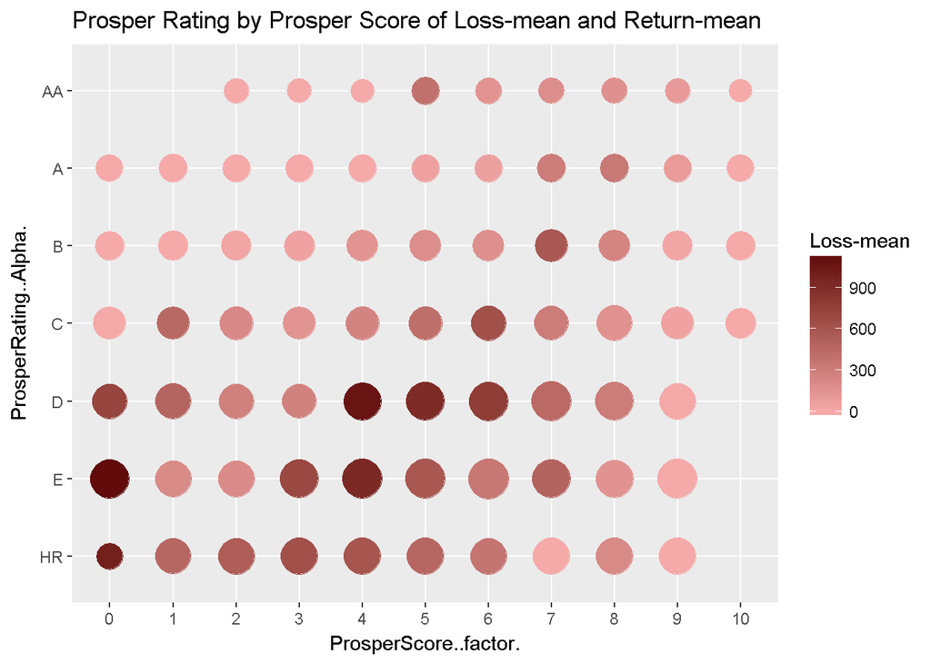

### 描述三

从HR-0到AA-10的粗略变化趋势是，高耗损和高回报-低耗损和低回报。再次强调，右下角的点表示着低耗损但是高回报，但结合风险-信用图来看，这种特征的点其实数量很稀少。看来低耗损-高回报，很难同时满足。

# 反思

起初，我总是希望寻找主要特征间的一定线性关系，但是有的变量间就是不会存在线性关系，例如拖欠时间和总耗损。后来我才反思到，当我们在接触数据集的时候，可以假想和推测，但不可以直接就肯定，要接受数据所表现出来的现象，尽管有的时候和推测并不一样。 但是这个表中因为一些原因，某些特征并不完整，例如信用评级和风险系数就有很多缺省值，而信用评级是分析中很重要的一个特征，因此得到的推测也很有局限性。若是可以补充客户的风险系数和信用评级，那么基于数据的分析则会更完善一些。正如上面分析看到的，信用评级和很多其他的特征都有或多或少的关系，如果可以更全面地搜集有关系的特征，例如收入借贷比，或者月收入，也许可以帮助完善信用评级的条目，当然其他未讨论的特征也许和信用评级也有关系（例如是否有房屋抵押），这需要进一步的分析确定。